# DengAI Data Preprocessing

Paul Y

01/03/2020

### *Some sources:*

https://rpubs.com/Jovial/R

https://www.youtube.com/watch?v=ONrGJF_8onw

https://www.youtube.com/watch?v=-tTJHRaPXxk

http://halweb.uc3m.es/esp/Personal/personas/jmmarin/esp/MasterMana/Pract1.pdf

https://towardsdatascience.com/simple-fast-exploratory-data-analysis-in-r-with-dataexplorer-package-e055348d9619

https://cran.r-project.org/web/packages/DataExplorer/vignettes/dataexplorer-intro.html

https://towardsdatascience.com/data-cleaning-with-r-and-the-tidyverse-detecting-missing-values-ea23c519bc62

## **Part 1: Data cleaning & Initial Analysis**

```r
dengue_train <- read.csv("dengue_features_train.csv", header = T, stringsAsFactors = F)
dengue_train_labels <- read.csv("dengue_labels_train.csv", header = T, stringsAsFactors = F)
dengue_test <- read.csv("dengue_features_test.csv", header = T, stringsAsFactors = F)
```

Merge the train & train_labels together. Create a null column total_cases in the testing data.

```r
dengue_train_merge <- merge(dengue_train, dengue_train_labels, by=c("city","year", "weekofyear"), all = TRUE)
dengue_test[,"total_cases"] <- NA
```

Glimpse of train data

```r
t(introduce(dengue_train_merge))
```

```
##                        [,1]
## rows                   1456
## columns                  25
## discrete_columns          2
## continuous_columns       23
## all_missing_columns       0
## total_missing_values    548
## complete_rows          1199
## total_observations    36400
## memory_usage         347424
```

Glimpse of test data

```r
t(introduce(dengue_test))
```

```
##                        [,1]
## rows                    416
## columns                  25
## discrete_columns          2
## continuous_columns       22
## all_missing_columns       1
## total_missing_values    535
## complete_rows             0
## total_observations    10400
## memory_usage         101984
```

Check the class of the other variables

```r
sapply(dengue_train_merge, class)
```

```
##                                  city                                  year
##                           "character"                             "integer"
##                            weekofyear                       week_start_date
##                             "integer"                           "character"
##                               ndvi_ne                               ndvi_nw
##                             "numeric"                             "numeric"
##                               ndvi_se                               ndvi_sw
##                             "numeric"                             "numeric"
##                  precipitation_amt_mm                 reanalysis_air_temp_k
##                             "numeric"                             "numeric"
##                 reanalysis_avg_temp_k           reanalysis_dew_point_temp_k
##                             "numeric"                             "numeric"
##             reanalysis_max_air_temp_k             reanalysis_min_air_temp_k
##                             "numeric"                             "numeric"
##       reanalysis_precip_amt_kg_per_m2  reanalysis_relative_humidity_percent
##                             "numeric"                             "numeric"
##          reanalysis_sat_precip_amt_mm reanalysis_specific_humidity_g_per_kg
##                             "numeric"                             "numeric"
##                     reanalysis_tdtr_k                    station_avg_temp_c
##                             "numeric"                             "numeric"
##               station_diur_temp_rng_c                    station_max_temp_c
##                             "numeric"                             "numeric"
##                    station_min_temp_c                     station_precip_mm
##                             "numeric"                             "numeric"
##                           total_cases
##                             "integer"
```

```r
dengue_train_merge <- remove_empty_cols(dengue_train_merge)
train_dim <- c(nrow(dengue_train_merge), ncol(dengue_train_merge))
test_dim <- c(nrow(dengue_test), ncol(dengue_test))
train_dim
```

```
## [1] 1456   25
```

```r
test_dim
```

```
## [1] 416  25
```

### Time for some Data Manipulation

Convert week_start_date to date class. Create columns for year, day, day of the year, month.

```r
dengue_train_merge$week_start_date <- as.Date(dengue_train_merge$week_start_date)
dengue_test$week_start_date <- as.Date(dengue_test$week_start_date)

dengue_train_merge$year <- format(dengue_train_merge$week_start_date, "%Y")
dengue_train_merge$month <- format(dengue_train_merge$week_start_date, "%b")
dengue_train_merge$day <- format(dengue_train_merge$week_start_date, "%d")
dengue_train_merge$day_of_year <- format(dengue_train_merge$week_start_date, "%j")

dengue_test$year <- format(dengue_test$week_start_date, "%Y")
dengue_test$month <- format(dengue_test$week_start_date, "%b")
dengue_test$day <- format(dengue_test$week_start_date, "%d")
dengue_test$day_of_year <- format(dengue_test$week_start_date, "%j")
```

Check if there are actually 52 weeks in each year

```r
dengue_train_merge[which(dengue_train_merge$weekofyear == "53"), 1:4]
```

```
##      city year weekofyear week_start_date
## 282    iq 2005         53      2005-01-01
## 516    iq 2010         53      2010-01-01
## 707    sj 1993         53      1993-01-01
## 1019   sj 1999         53      1999-01-01
## 1331   sj 2005         53      2005-01-01
```

```r
dengue_test[which(dengue_test$weekofyear == "53"), 1:4]
```

```
##    city year weekofyear week_start_date
## 88   sj 2010         53      2010-01-01
```

Upon viewing the data above, we have that the 53rd week of each year is actually the 1st day of each year. Let’s try to change these to the 1st week of their respective years to remain consistent with the data.

```r
dengue_train_merge$weekofyear[dengue_train_merge$weekofyear == "53"] <- "1"
dengue_test$weekofyear[dengue_test$weekofyear == "53"] <- "1"
```

The following columns are in Kelvin (K): reanalysis_air_temp_k, reanalysis_avg_temp_k, reanalysis_dew_point_temp_k, reanalysis_max_air_temp_k, reanalysis_min_air_temp_k, and reanalysis_tdtr_k. Let’s convert them to Centigrade (°C)

```r
for (i in c(10:14, 19)) {dengue_train_merge[,i] <- dengue_train_merge[,i] - 273.15}
for (i in c(10:14, 19)) {dengue_test[,i] <- dengue_test[,i] - 273.15}
```

Let’s now rename these columns using the tidyverse package

```r
dengue_train_merge <- dengue_train_merge %>%
  rename(
    ReaMeanAir_tempC = reanalysis_air_temp_k,
    ReaAvgAir_tempC = reanalysis_avg_temp_k,
    ReaMeanDewPoint_tempC = reanalysis_dew_point_temp_k,
    ReaMaxAir_tempC = reanalysis_max_air_temp_k,
    ReaMinAir_tempC = reanalysis_min_air_temp_k,
    ReaDiurRange_tempC = reanalysis_tdtr_k,
    )
head(dengue_train_merge, n=2)
```

```
##   city year weekofyear week_start_date   ndvi_ne   ndvi_nw   ndvi_se   ndvi_sw
## 1   iq 2000         26      2000-07-01 0.1928857 0.1322571 0.3408857 0.2472000
## 2   iq 2000         27      2000-07-08 0.2168333 0.2761000 0.2894571 0.2416571
##   precipitation_amt_mm ReaMeanAir_tempC ReaAvgAir_tempC ReaMeanDewPoint_tempC
## 1                25.41         23.59000        25.30000              22.03429
## 2                60.61         23.48429        25.27857              22.20857
##   ReaMaxAir_tempC ReaMinAir_tempC reanalysis_precip_amt_kg_per_m2
## 1           34.15           19.95                           43.19
## 2           33.45           17.95                           46.00
##   reanalysis_relative_humidity_percent reanalysis_sat_precip_amt_mm
## 1                             92.41857                        25.41
## 2                             93.58143                        60.61
##   reanalysis_specific_humidity_g_per_kg ReaDiurRange_tempC station_avg_temp_c
## 1                              16.65143          -264.2214               26.4
## 2                              16.86286          -262.8357               26.9
##   station_diur_temp_rng_c station_max_temp_c station_min_temp_c
## 1                10.77500               32.5               20.7
## 2                11.56667               34.0               20.8
##   station_precip_mm total_cases month day day_of_year
## 1               3.0           0   Jul  01         183
## 2              55.6           0   Jul  08         190
```

```r
dengue_test <- dengue_test %>%
  rename(
    ReaMeanAir_tempC = reanalysis_air_temp_k,
    ReaAvgAir_tempC = reanalysis_avg_temp_k,
    ReaMeanDewPoint_tempC = reanalysis_dew_point_temp_k,
    ReaMaxAir_tempC = reanalysis_max_air_temp_k,
    ReaMinAir_tempC = reanalysis_min_air_temp_k,
    ReaDiurRange_tempC = reanalysis_tdtr_k,
    )
```

We can rename other necessary columns for easier identification

```r
dengue_train_merge <- dengue_train_merge %>%
  rename(
    StaMax_tempC=station_max_temp_c,
    StaMin_tempC=station_min_temp_c,
    StaAvg_tempC=station_avg_temp_c,
    StaTotalPrecip_mm=station_precip_mm,
    StaDiurRange_tempC=station_diur_temp_rng_c,
    SatTotalPrecip_mm=precipitation_amt_mm,
    ReaTotalPrecip_mm=reanalysis_sat_precip_amt_mm,
    ReaMeanHum_percent=reanalysis_relative_humidity_percent,
    ReaMeaHum_perkg=reanalysis_specific_humidity_g_per_kg,
    ReaTotalPrecip_kgm2=reanalysis_precip_amt_kg_per_m2
    )
head(dengue_train_merge, n=2)
```

```
##   city year weekofyear week_start_date   ndvi_ne   ndvi_nw   ndvi_se   ndvi_sw
## 1   iq 2000         26      2000-07-01 0.1928857 0.1322571 0.3408857 0.2472000
## 2   iq 2000         27      2000-07-08 0.2168333 0.2761000 0.2894571 0.2416571
##   SatTotalPrecip_mm ReaMeanAir_tempC ReaAvgAir_tempC ReaMeanDewPoint_tempC
## 1             25.41         23.59000        25.30000              22.03429
## 2             60.61         23.48429        25.27857              22.20857
##   ReaMaxAir_tempC ReaMinAir_tempC ReaTotalPrecip_kgm2 ReaMeanHum_percent
## 1           34.15           19.95               43.19           92.41857
## 2           33.45           17.95               46.00           93.58143
##   ReaTotalPrecip_mm ReaMeaHum_perkg ReaDiurRange_tempC StaAvg_tempC
## 1             25.41        16.65143          -264.2214         26.4
## 2             60.61        16.86286          -262.8357         26.9
##   StaDiurRange_tempC StaMax_tempC StaMin_tempC StaTotalPrecip_mm total_cases
## 1           10.77500         32.5         20.7               3.0           0
## 2           11.56667         34.0         20.8              55.6           0
##   month day day_of_year
## 1   Jul  01         183
## 2   Jul  08         190
```

```r
dengue_test <- dengue_test %>%
  rename(
    StaMax_tempC=station_max_temp_c,
    StaMin_tempC=station_min_temp_c,
    StaAvg_tempC=station_avg_temp_c,
    StaTotalPrecip_mm=station_precip_mm,
    StaDiurRange_tempC=station_diur_temp_rng_c,
    SatTotalPrecip_mm=precipitation_amt_mm,
    ReaTotalPrecip_mm=reanalysis_sat_precip_amt_mm,
    ReaMeanHum_percent=reanalysis_relative_humidity_percent,
    ReaMeaHum_perkg=reanalysis_specific_humidity_g_per_kg,
    ReaTotalPrecip_kgm2=reanalysis_precip_amt_kg_per_m2
    )
```

Let’s reduce the features in the dataset by taking the averages of ReaMaxAir_tempC & ReaMinAir_tempC, StaMax_tempC & StaMin_tempC & appending new columns for them.

```r
dengue_train_merge$ReaAvgMaxMin_tempC <- rowMeans(dengue_train_merge[c('ReaMaxAir_tempC', 'ReaMinAir_tempC')], na.rm=TRUE)
dengue_train_merge$StaAvgMaxMin_tempC <- rowMeans(dengue_train_merge[c('StaMax_tempC', 'StaMin_tempC')], na.rm=TRUE)

dengue_train_merge <- dengue_train_merge[-c(13,14)]
dengue_train_merge <- dengue_train_merge[-c(20,21)]

dengue_test$ReaAvgMaxMin_tempC <- rowMeans(dengue_test[c('ReaMaxAir_tempC', 'ReaMinAir_tempC')], na.rm=TRUE)
dengue_test$StaAvgMaxMin_tempC <- rowMeans(dengue_test[c('StaMax_tempC', 'StaMin_tempC')], na.rm=TRUE)
dengue_test <- dengue_test[-c(13,14)]
dengue_test <- dengue_test[-c(20,21)]
```

Determine number of NAs & Nulls in each dataframe

```r
sum_na <- c(sum(is.na(dengue_train_merge)), sum(is.na(dengue_test)))
sum_null <- c(sum(is.null(dengue_train_merge)), sum(is.null(dengue_test)))
sum_na
```

```
## [1] 516 523
```

```r
sum_null
```

```
## [1] 0 0
```

Determine if there are rows where majority of the climate features are missing. Drop rows with 50% or more NA, just in our training set.

```r
dengue_train_merge <- dengue_train_merge[which(rowMeans(!is.na(dengue_train_merge)) >= 0.5), ]
```

Check which columns have NAs in them.

```r
sapply(dengue_train_merge, function(x) sum(is.na(x)))
```

```
##                  city                  year            weekofyear
##                     0                     0                     0
##       week_start_date               ndvi_ne               ndvi_nw
##                     0                   189                    47
##               ndvi_se               ndvi_sw     SatTotalPrecip_mm
##                    17                    17                     3
##      ReaMeanAir_tempC       ReaAvgAir_tempC ReaMeanDewPoint_tempC
##                     0                     0                     0
##   ReaTotalPrecip_kgm2    ReaMeanHum_percent     ReaTotalPrecip_mm
##                     0                     0                     3
##       ReaMeaHum_perkg    ReaDiurRange_tempC          StaAvg_tempC
##                     0                     0                    33
##    StaDiurRange_tempC     StaTotalPrecip_mm           total_cases
##                    33                    12                     0
##                 month                   day           day_of_year
##                     0                     0                     0
##    ReaAvgMaxMin_tempC    StaAvgMaxMin_tempC
##                     0                     2
```

```r
sum(is.na(dengue_train_merge$total_cases))
```

```
## [1] 0
```

Simply impute the null training set climate features by using the median.

```r
for(i in c(5:20,25,26)){dengue_train_merge[is.na(dengue_train_merge[,i]), i] <- median(dengue_train_merge[,i], na.rm = TRUE)}
sapply(dengue_train_merge, function(x) sum(is.na(x)))
```

```
##                  city                  year            weekofyear
##                     0                     0                     0
##       week_start_date               ndvi_ne               ndvi_nw
##                     0                     0                     0
##               ndvi_se               ndvi_sw     SatTotalPrecip_mm
##                     0                     0                     0
##      ReaMeanAir_tempC       ReaAvgAir_tempC ReaMeanDewPoint_tempC
##                     0                     0                     0
##   ReaTotalPrecip_kgm2    ReaMeanHum_percent     ReaTotalPrecip_mm
##                     0                     0                     0
##       ReaMeaHum_perkg    ReaDiurRange_tempC          StaAvg_tempC
##                     0                     0                     0
##    StaDiurRange_tempC     StaTotalPrecip_mm           total_cases
##                     0                     0                     0
##                 month                   day           day_of_year
##                     0                     0                     0
##    ReaAvgMaxMin_tempC    StaAvgMaxMin_tempC
##                     0                     0
```

Let us subset the data by city

```r
dengue_iq <- dengue_train_merge %>% filter(city == "iq")
dengue_sj <- dengue_train_merge %>% filter(city == "sj")
head(dengue_iq, n=2)
```

```
##   city year weekofyear week_start_date   ndvi_ne   ndvi_nw   ndvi_se   ndvi_sw
## 1   iq 2000         26      2000-07-01 0.1928857 0.1322571 0.3408857 0.2472000
## 2   iq 2000         27      2000-07-08 0.2168333 0.2761000 0.2894571 0.2416571
##   SatTotalPrecip_mm ReaMeanAir_tempC ReaAvgAir_tempC ReaMeanDewPoint_tempC
## 1             25.41         23.59000        25.30000              22.03429
## 2             60.61         23.48429        25.27857              22.20857
##   ReaTotalPrecip_kgm2 ReaMeanHum_percent ReaTotalPrecip_mm ReaMeaHum_perkg
## 1               43.19           92.41857             25.41        16.65143
## 2               46.00           93.58143             60.61        16.86286
##   ReaDiurRange_tempC StaAvg_tempC StaDiurRange_tempC StaTotalPrecip_mm
## 1          -264.2214         26.4           10.77500               3.0
## 2          -262.8357         26.9           11.56667              55.6
##   total_cases month day day_of_year ReaAvgMaxMin_tempC StaAvgMaxMin_tempC
## 1           0   Jul  01         183              27.05               26.6
## 2           0   Jul  08         190              25.70               27.4
```

```r
head(dengue_sj, n=2)
```

```
##   city year weekofyear week_start_date ndvi_ne  ndvi_nw   ndvi_se   ndvi_sw
## 1   sj 1990         18      1990-04-30  0.1226 0.103725 0.1984833 0.1776167
## 2   sj 1990         19      1990-05-07  0.1699 0.142175 0.1623571 0.1554857
##   SatTotalPrecip_mm ReaMeanAir_tempC ReaAvgAir_tempC ReaMeanDewPoint_tempC
## 1             12.42         24.42286        24.59286              19.26429
## 2             22.82         25.06143        25.29286              20.80143
##   ReaTotalPrecip_kgm2 ReaMeanHum_percent ReaTotalPrecip_mm ReaMeaHum_perkg
## 1               32.00           73.36571             12.42        14.01286
## 2               17.94           77.36857             22.82        15.37286
##   ReaDiurRange_tempC StaAvg_tempC StaDiurRange_tempC StaTotalPrecip_mm
## 1          -270.5214     25.44286           6.900000              16.0
## 2          -270.7786     26.71429           6.371429               8.6
##   total_cases month day day_of_year ReaAvgMaxMin_tempC StaAvgMaxMin_tempC
## 1           4   Apr  30         120               24.7              24.70
## 2           5   May  07         127               25.5              26.95
```

Rename datasets

```r
train_df <- dengue_train_merge
train_iq <- dengue_iq
train_sj <- dengue_sj
test_df <- dengue_test
```

Write these datasets to folder for future working purposes

```r
write.csv(train_df,"train_df.csv", row.names=FALSE)
write.csv(train_iq,"train_iq.csv", row.names=FALSE)
write.csv(train_sj,"train_sj.csv", row.names=FALSE)
write.csv(test_df,"test_df.csv", row.names=FALSE)
```

Get a quick introduction of our datasets one more time

```r
t(introduce(train_df)) # Training Set
```

```
##                        [,1]
## rows                   1446
## columns                  26
## discrete_columns          7
## continuous_columns       19
## all_missing_columns       0
## total_missing_values      0
## complete_rows          1446
## total_observations    37596
## memory_usage         311064
```

```r
t(introduce(train_iq)) # Iquitos Training Set
```

```
##                        [,1]
## rows                    516
## columns                  26
## discrete_columns          7
## continuous_columns       19
## all_missing_columns       0
## total_missing_values      0
## complete_rows           516
## total_observations    13416
## memory_usage         120728
```

```r
t(introduce(train_sj)) # San Juan Training Set
```

```
##                        [,1]
## rows                    930
## columns                  26
## discrete_columns          7
## continuous_columns       19
## all_missing_columns       0
## total_missing_values      0
## complete_rows           930
## total_observations    24180
## memory_usage         205632
```

```r
t(introduce(test_df))
```

```
##                        [,1]
## rows                    416
## columns                  26
## discrete_columns          7
## continuous_columns       18
## all_missing_columns       1
## total_missing_values    523
## complete_rows             0
## total_observations    10816
## memory_usage         100104
```

```r
as.data.frame(sapply(train_df, class))
```

```
##                       sapply(train_df, class)
## city                                character
## year                                character
## weekofyear                          character
## week_start_date                          Date
## ndvi_ne                               numeric
## ndvi_nw                               numeric
## ndvi_se                               numeric
## ndvi_sw                               numeric
## SatTotalPrecip_mm                     numeric
## ReaMeanAir_tempC                      numeric
## ReaAvgAir_tempC                       numeric
## ReaMeanDewPoint_tempC                 numeric
## ReaTotalPrecip_kgm2                   numeric
## ReaMeanHum_percent                    numeric
## ReaTotalPrecip_mm                     numeric
## ReaMeaHum_perkg                       numeric
## ReaDiurRange_tempC                    numeric
## StaAvg_tempC                          numeric
## StaDiurRange_tempC                    numeric
## StaTotalPrecip_mm                     numeric
## total_cases                           integer
## month                               character
## day                                 character
## day_of_year                         character
## ReaAvgMaxMin_tempC                    numeric
## StaAvgMaxMin_tempC                    numeric
```

```r
as.data.frame(sapply(test_df, class))
```

```
##                       sapply(test_df, class)
## city                               character
## year                               character
## weekofyear                         character
## week_start_date                         Date
## ndvi_ne                              numeric
## ndvi_nw                              numeric
## ndvi_se                              numeric
## ndvi_sw                              numeric
## SatTotalPrecip_mm                    numeric
## ReaMeanAir_tempC                     numeric
## ReaAvgAir_tempC                      numeric
## ReaMeanDewPoint_tempC                numeric
## ReaTotalPrecip_kgm2                  numeric
## ReaMeanHum_percent                   numeric
## ReaTotalPrecip_mm                    numeric
## ReaMeaHum_perkg                      numeric
## ReaDiurRange_tempC                   numeric
## StaAvg_tempC                         numeric
## StaDiurRange_tempC                   numeric
## StaTotalPrecip_mm                    numeric
## total_cases                          logical
## month                              character
## day                                character
## day_of_year                        character
## ReaAvgMaxMin_tempC                   numeric
## StaAvgMaxMin_tempC                   numeric
```

## **Part 2: Data Visualization and Further Analysis**

Plot frequency of our target variable total_cases by year in each set.

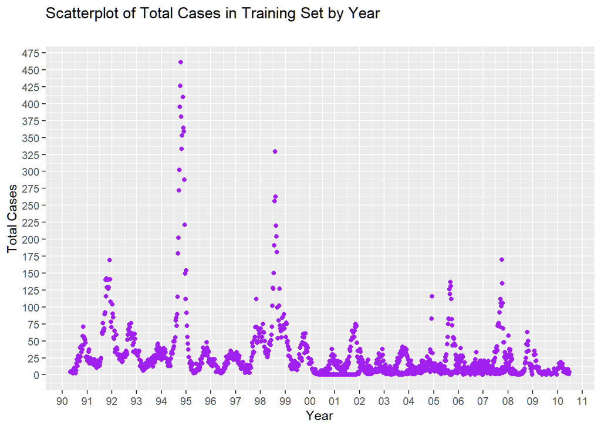

```r
scatter_train <- ggplot(data = train_df, aes(x = week_start_date, y = total_cases)) +
  geom_point(color = "purple") +
  labs(x = "Year",
    y = "Total Cases",
    title = "Scatterplot of Total Cases in Training Set by Year",
    subtitle = "")
scatter_train + scale_x_date(date_breaks = "1 year", date_labels = "%y") + scale_y_continuous(breaks=seq(0, 475, 25))
```

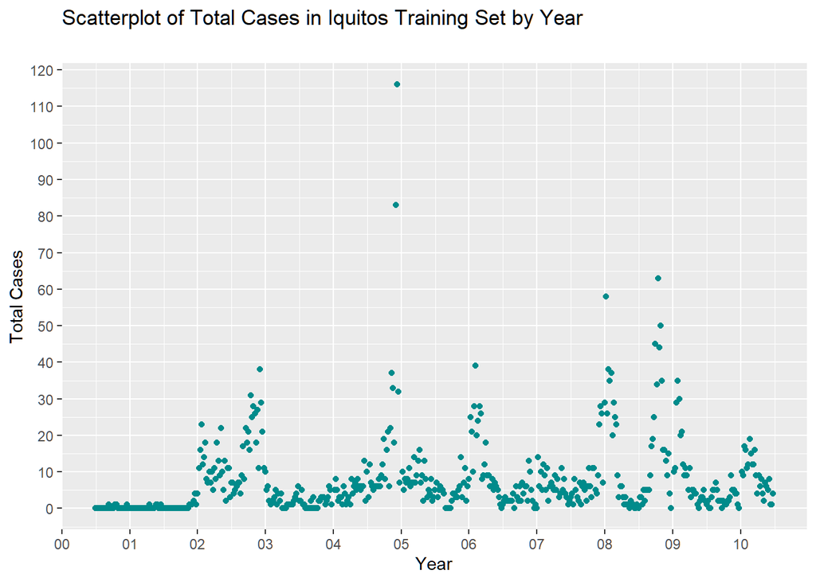

```r
scatter_iq <- ggplot(data = train_iq, aes(x = week_start_date, y = total_cases)) +
  geom_point(color = "darkcyan") +
  labs(x = "Year",
    y = "Total Cases",
    title = "Scatterplot of Total Cases in Iquitos Training Set by Year",
    subtitle = "")
scatter_iq + scale_x_date(date_breaks = "1 year", date_labels = "%y") + scale_y_continuous(breaks=seq(0, 200, 10))
```

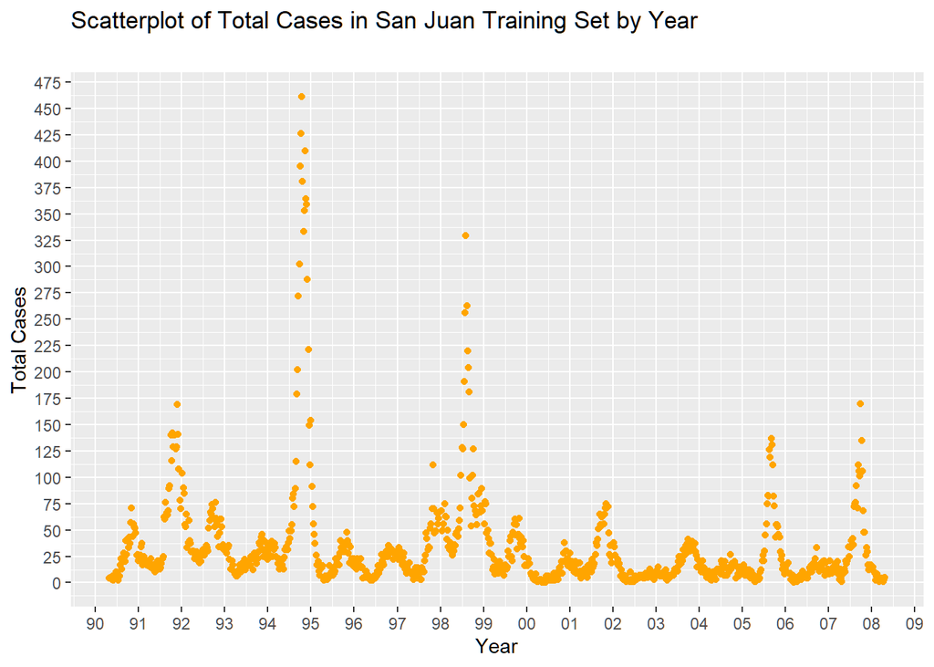

```r
scatter_sj <- ggplot(data = train_sj, aes(x = week_start_date, y = total_cases)) +
  geom_point(color = "orange") +
  labs(x = "Year",
    y = "Total Cases",
    title = "Scatterplot of Total Cases in San Juan Training Set by Year",
    subtitle = "")
scatter_sj + scale_x_date(date_breaks = "1 year", date_labels = "%y") + scale_y_continuous(breaks=seq(0, 475, 25))
```

### Time for some correlation analysis

Let’s visualize the correlation matrix in our training set. Focus on the total_cases variable.

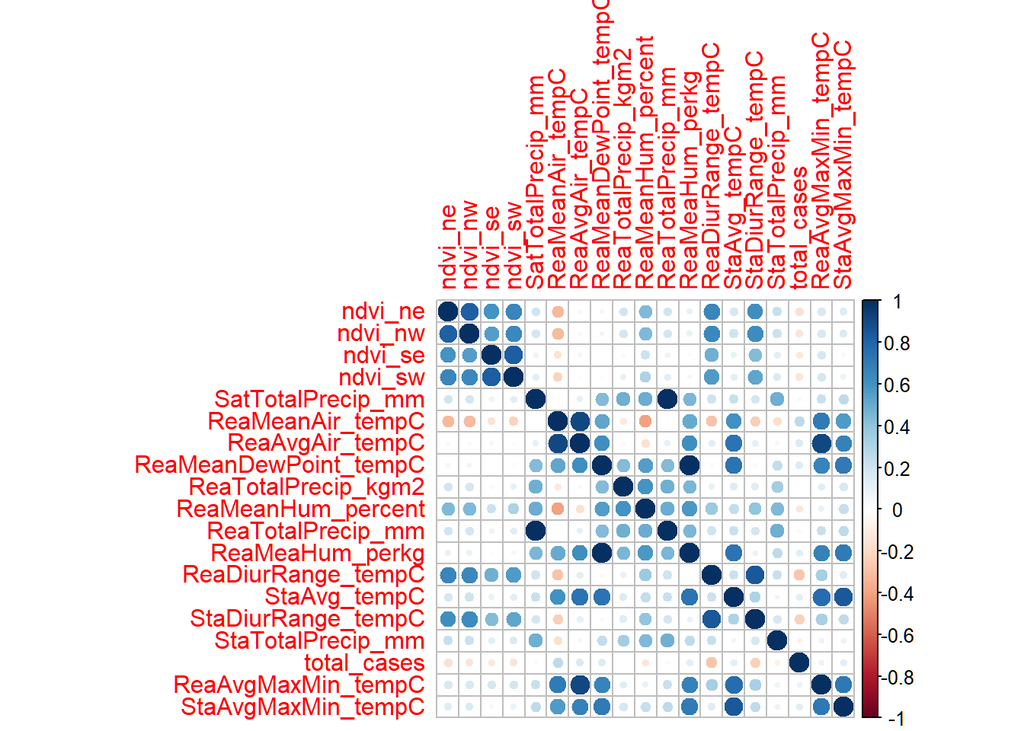

```r
cor.mat.df <- cor(train_df[, c(5:21,25:26)])
corrplot(cor.mat.df)
```

Correlate total_cases with climate features in the Iquitos and San Juan training sets. Source: https://www.displayr.com/how-to-create-a-correlation-matrix-in-r/ Source: https://rpkgs.datanovia.com/rstatix/reference/cor_mat.html and package rstatix.

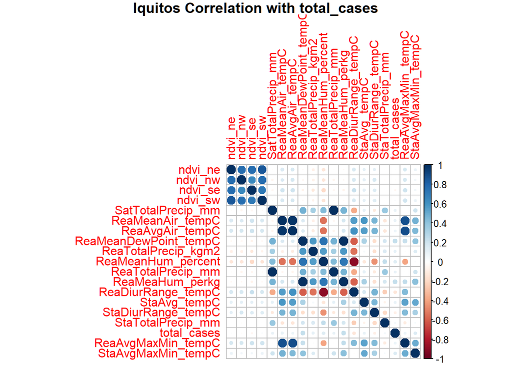

```r
cor.mat.iq <- cor(train_iq[, c(5:21,25:26)])
corrplot(cor.mat.iq, title = "Iquitos Correlation with total_cases", mar=c(0,0,1,0) ) # Iquitos correlation
```

```r
cor.mat.iq.df <- as.data.frame(cor.mat.iq)
cor.iq <- as.data.frame(cbind(total_cases_cor_iq = cor.mat.iq.df$total_cases, features_iq = colnames(cor.mat.iq.df[,1:ncol(cor.mat.iq.df)]))) # determine total_cases correlation values with other climate features in Iquitos
cor.iq$total_cases_cor_iq <-as.numeric(as.character(cor.iq[,1]))
cor.iq %>%
   arrange(desc(abs(cor.iq$total_cases_cor_iq)))
```

```
##    total_cases_cor_iq           features_iq
## 1          1.00000000           total_cases
## 2          0.23647605       ReaMeaHum_perkg
## 3          0.23040141 ReaMeanDewPoint_tempC
## 4          0.14976252    StaAvgMaxMin_tempC
## 5         -0.13442453    ReaDiurRange_tempC
## 6          0.13008274    ReaMeanHum_percent
## 7          0.10117149   ReaTotalPrecip_kgm2
## 8          0.09709779      ReaMeanAir_tempC
## 9          0.09317420          StaAvg_tempC
## 10         0.09017051     SatTotalPrecip_mm
## 11         0.09017051     ReaTotalPrecip_mm
## 12        -0.08830805    StaDiurRange_tempC
## 13         0.07987174       ReaAvgAir_tempC
## 14         0.07814355    ReaAvgMaxMin_tempC
## 15         0.04371339     StaTotalPrecip_mm
## 16        -0.04320762               ndvi_se
## 17         0.02977652               ndvi_sw
## 18         0.01677719               ndvi_ne
## 19        -0.01231263               ndvi_nw
```

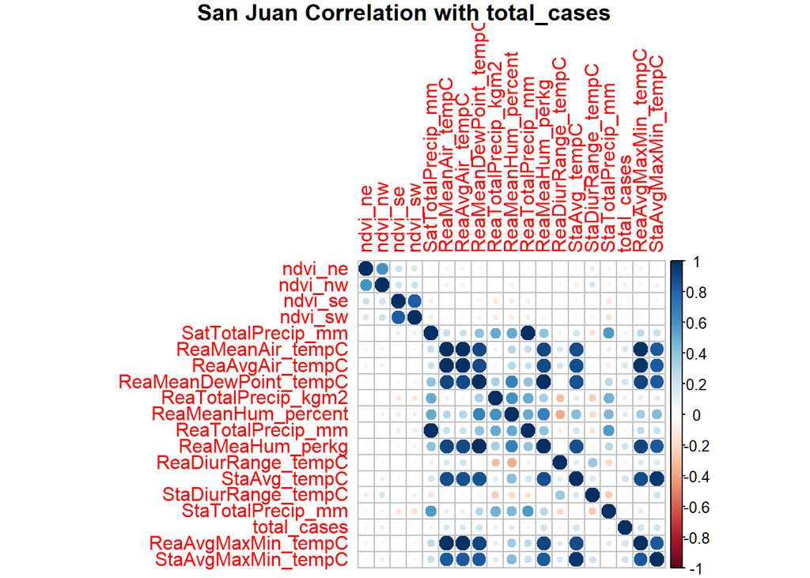

```r
cor.mat.sj <- cor(train_sj[, c(5:21,25:26)])
corrplot(cor.mat.sj, title = "San Juan Correlation with total_cases", mar=c(0,0,1,0) ) # San Juan correlation
```

```r
cor.mat.sj.df <- as.data.frame(cor.mat.sj)
cor.sj <- as.data.frame(cbind(total_cases_cor_sj = cor.mat.sj.df$total_cases, features_sj = colnames(cor.mat.sj.df[,1:ncol(cor.mat.sj.df)]))) # determine total_cases correlation values with other climate features in San Juan
cor.sj$total_cases_cor_sj <-as.numeric(as.character(cor.sj[,1]))
cor.sj %>%
   arrange(desc(abs(cor.sj$total_cases_cor_sj)))
```

```
##    total_cases_cor_sj           features_sj
## 1          1.00000000           total_cases
## 2          0.20794741       ReaMeaHum_perkg
## 3          0.20377424 ReaMeanDewPoint_tempC
## 4          0.20096266    StaAvgMaxMin_tempC
## 5          0.19995582    ReaAvgMaxMin_tempC
## 6          0.19661656          StaAvg_tempC
## 7          0.18191695      ReaMeanAir_tempC
## 8          0.17526745       ReaAvgAir_tempC
## 9          0.14404470    ReaMeanHum_percent
## 10         0.10745738   ReaTotalPrecip_kgm2
## 11         0.09738748               ndvi_nw
## 12        -0.06759993    ReaDiurRange_tempC
## 13         0.06520378               ndvi_ne
## 14         0.06024369     SatTotalPrecip_mm
## 15         0.06024369     ReaTotalPrecip_mm
## 16         0.05175921     StaTotalPrecip_mm
## 17         0.03667258               ndvi_sw
## 18         0.03463007    StaDiurRange_tempC
## 19         0.02905592               ndvi_se
```

Visually, we don’t have very strong features that correlate well with total_cases. We sort the total_cases correlation in Iquitos and San Juan training set with the highest absolute values, as we want the features closest to 1 being the strongest for our model. The following features seem useful for the Iquitos model: ReaMeaHum_perkg, ReaMeanDewPoint_tempC, ReaMeanDewPoint_tempC, StaAvgMaxMin_tempC, ReaDiurRange_tempC, ReaMeanHum_percent, ReaTotalPrecip_kgm2. The following features seem useful for the San Juan model: ReaMeaHum_perkg, ReaMeanDewPoint_tempC, StaAvgMaxMin_tempC, ReaAvgMaxMin_tempC, StaAvg_tempC, ReaMeanAir_tempC, ReaAvgAir_tempC, ReaMeanHum_percent, ReaTotalPrecip_kgm2.

Let’s make our analysis stronger by extracting significance levels (p-values) using package Hmisc: Harrell Miscellaneous.

```r
rcorr_iq <- rcorr(as.matrix(train_iq[, c(5:21,25:26)]))
rcorr_sj <- rcorr(as.matrix(train_sj[, c(5:21,25:26)]))
```

We will be using a function to format the correlation matrix, which displays the correlation and p-value in a neat dataframe. The following function is sourced from this site. http://www.sthda.com/english/wiki/correlation-matrix-a-quick-start-guide-to-analyze-format-and-visualize-a-correlation-matrix-using-r-software

```r
# ++++++++++++++++++++++++++++
# flattenCorrMatrix
# ++++++++++++++++++++++++++++
# cormat : matrix of the correlation coefficients
# pmat : matrix of the correlation p-values
flattenCorrMatrix <- function(cormat, pmat) {
  ut <- upper.tri(cormat)
  data.frame(
    row = rownames(cormat)[row(cormat)[ut]],
    column = rownames(cormat)[col(cormat)[ut]],
    cor  =(cormat)[ut],
    p = pmat[ut]
    )
}
```

Extract the p-values & correlation from both cities with target variable total_cases. We sort the dataset by ascending p-value. Features with lower p-values implies higher significance of the predictor variable in correlation with the target variable.

```r
IQ <- flattenCorrMatrix(rcorr_iq$r, rcorr_iq$P)
sub_iq <- subset(IQ , column=="total_cases")
sub_iq[order(sub_iq$p), ] # Sort Iquitos training set by ascending p-values
```

```
##                       row      column         cor            p
## 132       ReaMeaHum_perkg total_cases  0.23647605 5.450142e-08
## 128 ReaMeanDewPoint_tempC total_cases  0.23040141 1.207289e-07
## 133    ReaDiurRange_tempC total_cases -0.13442453 2.213131e-03
## 130    ReaMeanHum_percent total_cases  0.13008274 3.073064e-03
## 129   ReaTotalPrecip_kgm2 total_cases  0.10117149 2.153327e-02
## 126      ReaMeanAir_tempC total_cases  0.09709779 2.741887e-02
## 134          StaAvg_tempC total_cases  0.09317420 3.434627e-02
## 125     SatTotalPrecip_mm total_cases  0.09017051 4.061046e-02
## 131     ReaTotalPrecip_mm total_cases  0.09017051 4.061046e-02
## 135    StaDiurRange_tempC total_cases -0.08830805 4.496015e-02
## 127       ReaAvgAir_tempC total_cases  0.07987174 6.985741e-02
## 136     StaTotalPrecip_mm total_cases  0.04371339 3.216646e-01
## 123               ndvi_se total_cases -0.04320762 3.273005e-01
## 124               ndvi_sw total_cases  0.02977652 4.997382e-01
## 121               ndvi_ne total_cases  0.01677719 7.037918e-01
## 122               ndvi_nw total_cases -0.01231263 7.802283e-01
```

```r
SJ <- flattenCorrMatrix(rcorr_sj$r, rcorr_sj$P)
sub_sj <- subset(SJ , column=="total_cases")
sub_sj[order(sub_sj$p), ] # Sort Iquitos training set by ascending p-values
```

```
##                       row      column         cor            p
## 132       ReaMeaHum_perkg total_cases  0.20794741 1.522173e-10
## 128 ReaMeanDewPoint_tempC total_cases  0.20377424 3.568019e-10
## 134          StaAvg_tempC total_cases  0.19661656 1.475172e-09
## 126      ReaMeanAir_tempC total_cases  0.18191695 2.311032e-08
## 127       ReaAvgAir_tempC total_cases  0.17526745 7.471670e-08
## 130    ReaMeanHum_percent total_cases  0.14404470 1.034269e-05
## 129   ReaTotalPrecip_kgm2 total_cases  0.10745738 1.030334e-03
## 122               ndvi_nw total_cases  0.09738748 2.949100e-03
## 133    ReaDiurRange_tempC total_cases -0.06759993 3.929291e-02
## 121               ndvi_ne total_cases  0.06520378 4.682393e-02
## 125     SatTotalPrecip_mm total_cases  0.06024369 6.630103e-02
## 131     ReaTotalPrecip_mm total_cases  0.06024369 6.630103e-02
## 136     StaTotalPrecip_mm total_cases  0.05175921 1.147085e-01
## 124               ndvi_sw total_cases  0.03667258 2.638939e-01
## 135    StaDiurRange_tempC total_cases  0.03463007 2.914385e-01
## 123               ndvi_se total_cases  0.02905592 3.761126e-01
```

```r
# you can use the function attach(df) so that the database is searched by R when evaluating a variable; no need to specify df$col_name in a function, just simply give the col_name.
```